# Normalization performance report

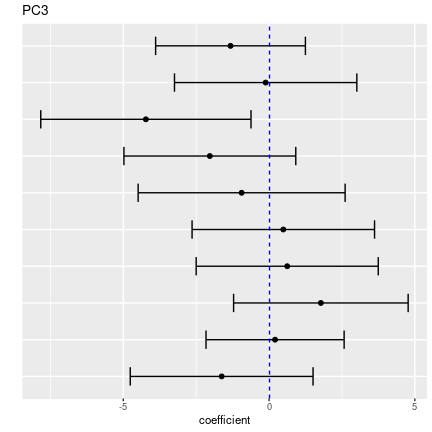

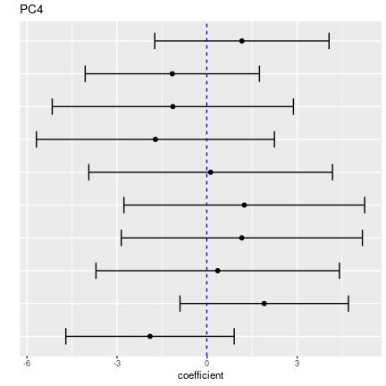

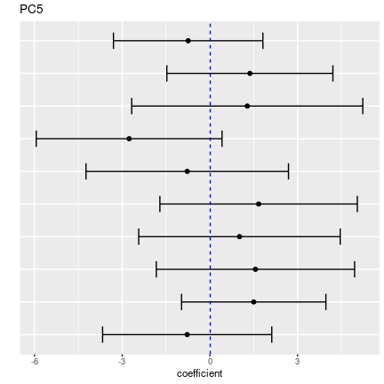

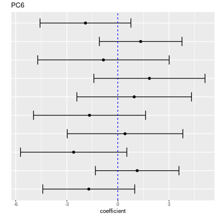

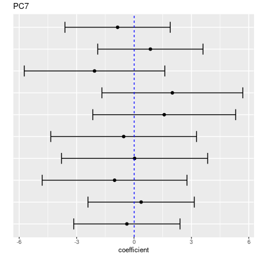

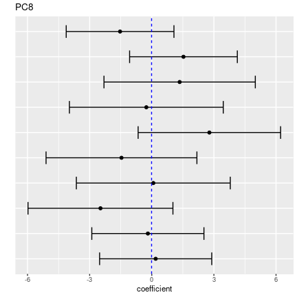

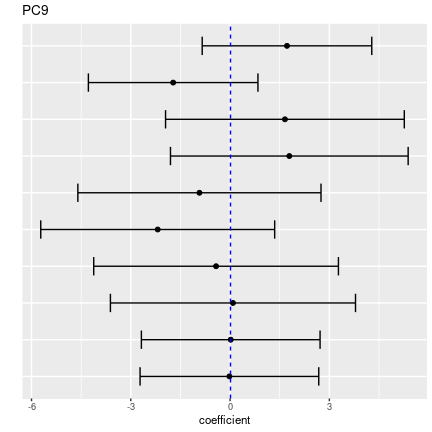

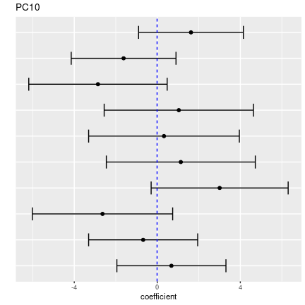

| batch.variable | batch.value | principal.component | test | p.value | estimate | lower | upper | r2 |
| --- | --- | --- | --- | --- | --- | --- | --- | --- |
| sentrix_row | 02 | PC1 | t-test | 0.00439 | -9.05 | -15.7 | -2.36 | 0.371 |